## Texterna

#### Vad sjunger Mello om?

Du kanske redan har gissat det. I ett enda ord: *kärlek*. Inget annat ämne är så populärt i Melodifestivalen som att sjunga om något man verkligen älskar. Oavsett om det handlar om [bitterljuva minnen](http://www.svt.se/melodifestivalen/bidragsbibeln-yohio-heartbreak-hotel), kärleken till [förlorade bröder](http://www.svt.se/melodifestivalen/artister/2014/linus-svenning/bidragsbibeln-linus-svenning-broder) eller helt enkelt [rå passion](http://www.svt.se/melodifestivalen/artister/2014/eko/bidragsbibeln-eko-red). Bara för att ta några exempel.

Ironiskt nog kunde man kanske tro att kärlekstemat också skulle innebära att texterna i Mello generellt är glada, men Mello-artisterna tycks vara minst lika förtjusta i att sjunga om smärta som om hjärta.

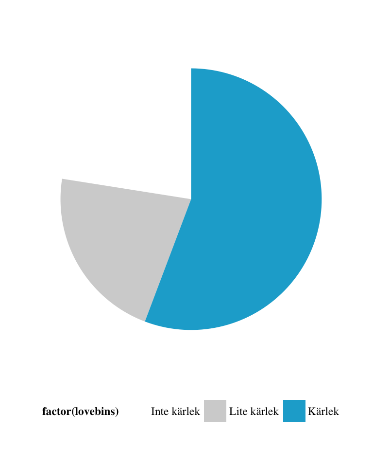

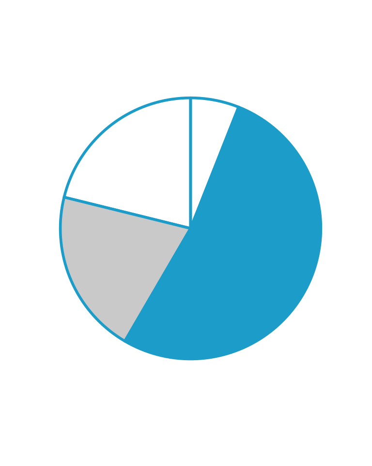